# Graphs-ordinal variables

#### Learning Objectives

By the end of this section you should be able to:

- Plot ordinal variables using ggplot2
- Change or adjust the labels of a variable
- Use the density plot to represent ordinal variables.

In this section we will use two variables describing anti-immigration attitudes, the first one is called `v184` and is asking respondents to agree or diagree with the following statement *“Immigrants take away jobs”*. The second variable is called `v186` and is asking respondents whether *“Immigrants are responsible for crime”*.

```r
names(EVS_UK)[names(EVS_UK) == "v184"] <- "immi_jobs"

table(EVS_UK$immi_jobs) # This is to check whether the function was correctly specified
```

```
##
##   1   2   3   4   5
##  71 197 631 610 272
```

We may add labels to the values using the functions we used at section 1:

```r
EVS_UK$immi_jobs <- ordered(EVS_UK$immi_jobs,#here you specify that this is ordered variable
levels = c(1,2,3,4,5), # here you specify the values of the variable
labels = c("Completely agree", "Agree", "Neither/nor","Disagree", "Completely disagree" ))  #here you specify the names of the values

table(EVS_UK$immi_jobs)
```

```
##
##    Completely agree               Agree         Neither/nor            Disagree
##                  71                 197                 631                 610
## Completely disagree
##                 272
```

We will do the same for the variable describing whether “Immigrants tare responsible for crime”.

```r
EVS_UK$immi_crime <- ordered(EVS_UK$v186,#here you specify that this is ordered variable
levels = c(1,2,3,4,5),# here you specify the values of the variable
labels = c("Completely agree", "Agree", "Neither/nor","Disagree", "Completely disagree" ))  #here you specify the names of the values

table(EVS_UK$immi_jobs)
```

```
##
##    Completely agree               Agree         Neither/nor            Disagree
##                  71                 197                 631                 610
## Completely disagree
##                 272
```

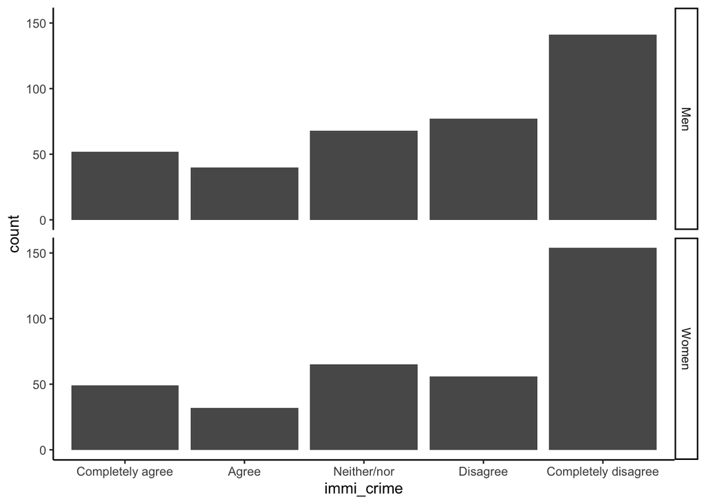

```r
plot3<-ggplot(na.omit(EVS_UK), aes(x = immi_crime),na.rm = TRUE) + geom_bar() + facet_grid(gender ~.)+
  theme_classic() #The na.omit() function will remove NAs

plot3
```

### Density Plots

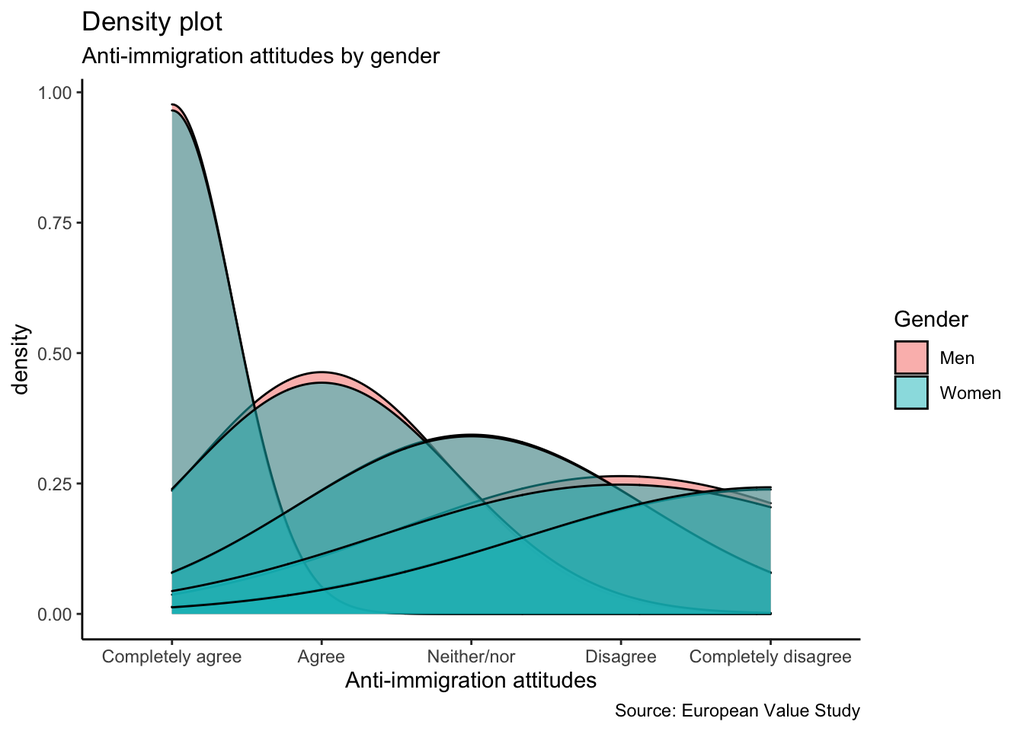

```r
plot4 <- ggplot(na.omit(EVS_UK), aes(immi_crime))

plot4 + geom_density(aes(fill=factor(gender)), alpha=0.5) +
    labs(title="Density plot",
         subtitle="Anti-immigration attitudes by gender",
         caption="Source: European Value Study",
         x="Anti-immigration attitudes",
         fill="Gender")+
  theme_classic()
```

# Recap

- You can plot ordinal data using `geom_density()` in ggplot2.
- You can adjust or rename the ordinal data using the `ordered`,`levels` and `labels` functions in R.